# Two-Sample Medians

## Introduction: Topics

- We previously have reviewed estimation and basic statistical inference.
  - Point estimation
  - Confidence intervals
  - Hypothesis testing
- Today we will focus on the following scenarios today:
  - Two-sample medians, independent data ($M_1-M_2$)
  - Two-sample medians, dependent data ($M_d$)

## Introduction: Data

- The Wonderbolts have opened a new Reserve Camp, where 30 cadets spend two weeks training for a shot at the main squad.
- On arrival, each cadet is assigned to one of two training squadrons:
  - Thunder Squadron
  - Lightning Squadron
- The two squadrons train separately and compete against each other in a series of trials.
  - Independent data
- Every cadet is also measured once at the start of camp and once again at the end, after two weeks of identical drills.
  - Dependent data

## Introduction: Data

- Eyeballing the dataset,

| cadet_name | squadron | sprint_time_sec | loop_accuracy_pct | prize_bits_won | cheer_decibels | injury_days | wing_flap_rate_pre | wing_flap_rate_post | accuracy_score_pre | accuracy_score_post | confidence_rating_pre | confidence_rating_post | recovery_time_min_pre | recovery_time_min_post | tip_bits_pre | tip_bits_post |
| --- | --- | --- | --- | --- | --- | --- | --- | --- | --- | --- | --- | --- | --- | --- | --- | --- |
| Rainbow Dash | Thunder Squadron | 39.6 | 86.4 | 5 | 91.8 | 0 | 49.2 | 49.8 | 79.7 | 94.4 | 7 | 8 | 21.6 | 19.8 | 4 | 23 |
| Soarin | Thunder Squadron | 40.0 | 83.2 | 86 | 87.1 | 2 | 76.1 | 75.6 | 75.5 | 85.9 | 8 | 9 | 3.1 | 1.0 | 18 | 45 |
| Spitfire | Thunder Squadron | 38.7 | 81.8 | 12 | 89.6 | 1 | 55.9 | 59.6 | 73.1 | 71.4 | 8 | 10 | 17.2 | 14.5 | 3 | 8 |
| Cloudchaser | Thunder Squadron | 40.0 | 73.7 | 20 | 89.6 | 3 | 45.1 | 47.6 | 56.5 | 61.9 | 5 | 5 | 6.9 | 2.7 | 17 | 53 |
| Fleetfoot | Thunder Squadron | 39.4 | 85.3 | 16 | 89.3 | 3 | 44.6 | 39.4 | 61.8 | 63.5 | 7 | 8 | 33.5 | 30.7 | 13 | 30 |
| Lightning Dust | Thunder Squadron | 45.8 | 86.4 | 22 | 92.4 | 2 | 48.3 | 58.0 | 66.4 | 73.0 | 5 | 7 | 6.1 | 1.6 | 4 | 10 |

## The Normality Assumption

- All *t*-tests assume approximate normality of the data.
  - In the case of one-sample *t*-tests, the measure of interest must somewhat follow a normal distribution.
  - In the case of two-sample *t*-tests, the measure of interest *in each group* must somewhat follow a normal distribution.
- Note that a paired *t*-test is technically a one-sample *t*-test, so we will examine normality of the difference.

## Normality Assumption: Quantile-Quantile Plots

- There are formal tests for normality ([see article here](https://www.ncbi.nlm.nih.gov/pmc/articles/PMC3693611/)), however, we will not use them.
- Instead, we will assess normality using a quantile-quantile (Q-Q) plot.
  - A Q-Q plot helps us visually check if our data follows a specific distribution (here, the normal).
- How do we read Q-Q plots?
  - Each dot represents one observation in our dataset.
  - If the data follow a normal distribution, we will observe that the dots fall roughly along a straight diagonal line.
  - We focus on the “middle” of the graph.

## Normality Assumption: Quantile-Quantile Plots

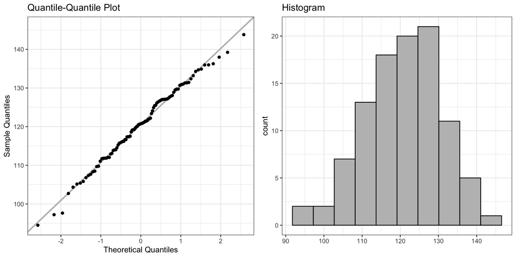

## Normality Assumption: Quantile-Quantile Plots

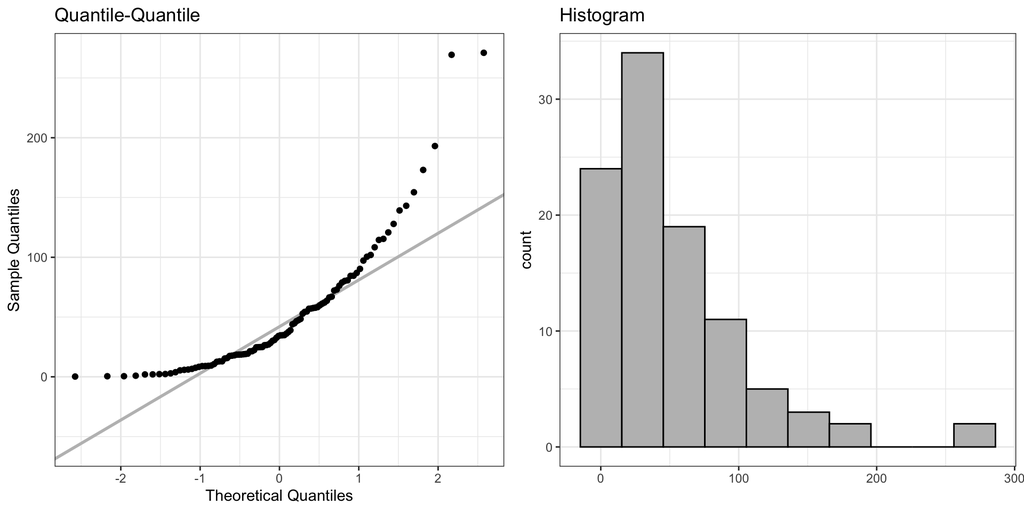

## Normality Assumption: Quantile-Quantile Plots

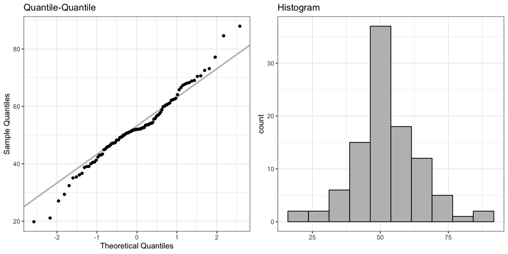

## Normality Assumption: Quantile-Quantile Plots

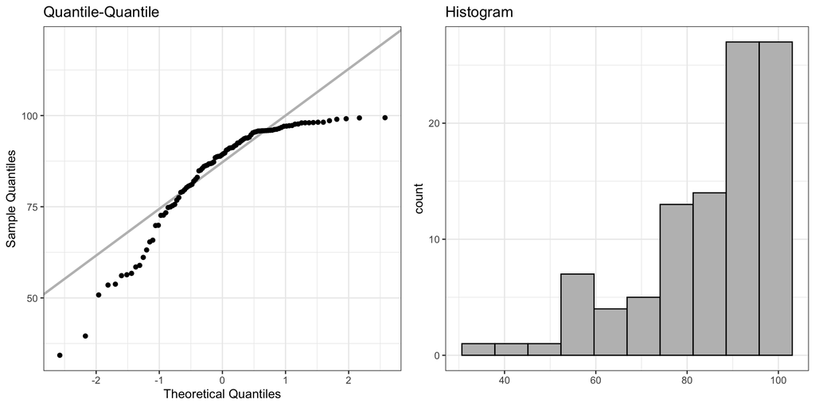

## Normality Assumption (`R`)

- We will check this graphically.
- For independent data,

```r
dataset_name |> independent_qq(outcome = outcome_variable,
                               grouping = grouping_variable)
```

- For dependent data,

```r
dataset_name |> dependent_qq(col1 = first_measurement,
                             col2 = second_measurement)
```

## Example 1

- Every cadet runs a timed sprint course as part of camp trials.
- The coaches want us to determine if the Thunder Squadron and Lightning Squadron are finishing the sprint course at different times.
- Looking at the data,

| cadet_name | squadron | sprint_time_sec |
| --- | --- | --- |
| Rainbow Dash | Thunder Squadron | 39.6 |
| Soarin | Thunder Squadron | 40.0 |
| Spitfire | Thunder Squadron | 38.7 |
| Cloudchaser | Thunder Squadron | 40.0 |
| Fleetfoot | Thunder Squadron | 39.4 |

## Example 1

- Checking the normality assumption,

```r
wonderbolt_camp |> independent_qq(outcome = sprint_time_sec,
                                  grouping = squadron)
```

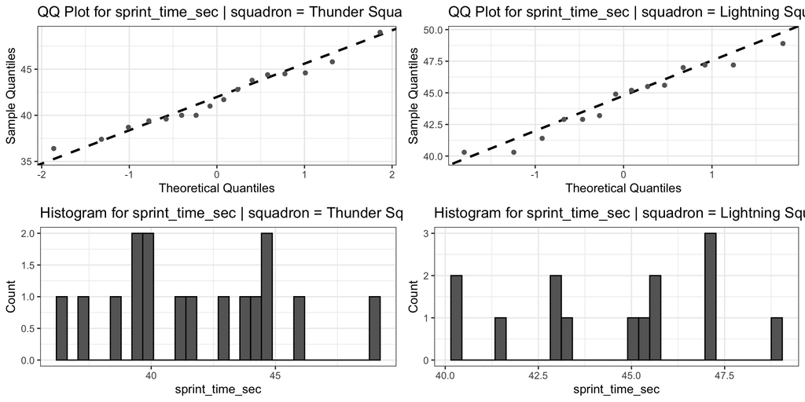

## Example 2

- At camp, judges score each cadet’s aerial loop maneuver on a 0–100 accuracy scale during trials.
- Based on her gut feeling, the head judge believes that, on average, the Thunder Squadron is performing more accurate loop maneuvers.
- Looking at the data,

| cadet_name | squadron | loop_accuracy_pct |
| --- | --- | --- |
| Rainbow Dash | Thunder Squadron | 86.4 |
| Soarin | Thunder Squadron | 83.2 |
| Spitfire | Thunder Squadron | 81.8 |
| Cloudchaser | Thunder Squadron | 73.7 |
| Fleetfoot | Thunder Squadron | 85.3 |

## Example 2

- Checking the normality assumption,

```r
wonderbolt_camp |> independent_qq(outcome = loop_accuracy_pct,
                                  grouping = squadron)
```

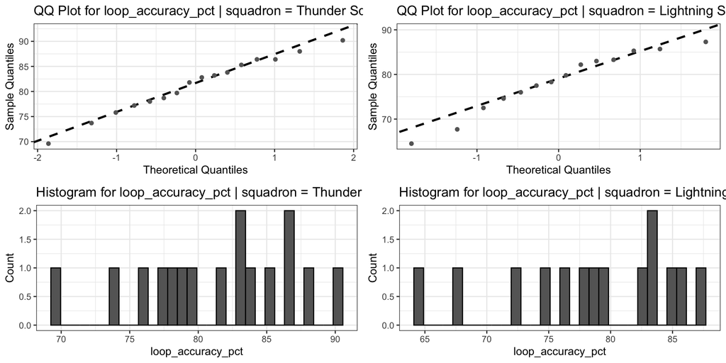

## Example 3

- Each cadet’s aerial accuracy is scored when they arrive at camp, and scored again at the end after two weeks of drills.
- Coaches want to know whether cadets are actually flying more accurately by the end of camp.
- Looking at the data,

| cadet_name | accuracy_score_pre | accuracy_score_post |
| --- | --- | --- |
| Rainbow Dash | 79.7 | 94.4 |
| Soarin | 75.5 | 85.9 |
| Spitfire | 73.1 | 71.4 |
| Cloudchaser | 56.5 | 61.9 |
| Fleetfoot | 61.8 | 63.5 |

## Example 3

- Checking the normality assumption,

```r
wonderbolt_camp |> dependent_qq(col1 = accuracy_score_pre,
                                col2 = accuracy_score_post)
```

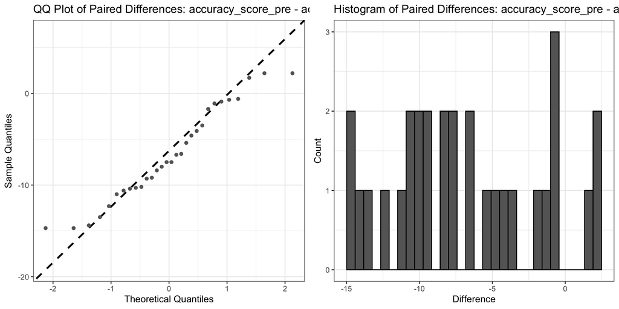

## Example 4

- Each cadet’s recovery time after a hard trial is timed at the start of camp and again at the end.
- Coaches want to know whether cadets are recovering faster by the end of camp.
- Looking at the data,

| cadet_name | recovery_time_min_pre | recovery_time_min_post |
| --- | --- | --- |
| Rainbow Dash | 21.6 | 19.8 |
| Soarin | 3.1 | 1.0 |
| Spitfire | 17.2 | 14.5 |
| Cloudchaser | 6.9 | 2.7 |
| Fleetfoot | 33.5 | 30.7 |

## Example 4

- Checking the normality assumption,

```r
wonderbolt_camp |> dependent_qq(col1 = recovery_time_min_pre,
                                col2 = recovery_time_min_post)
```

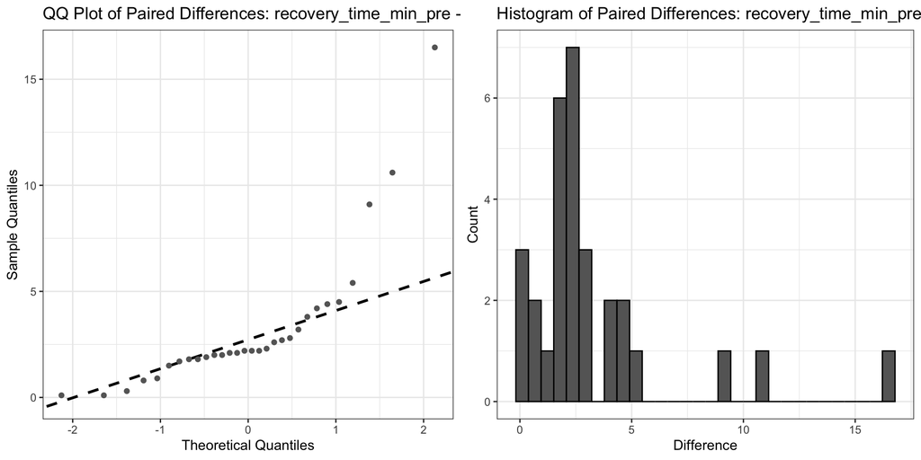